# Rmarkdown1

Lucas Nobre

28 de janeiro de 2019

# Predicting Graduate Admissions

## About the dataset

This dataset is created for prediction of Graduate Admissions from an Indian perspective

### Content

Contains several parameters which are considered important during applications for Masters programs.The parameters are: GRE Scores, TOEFL Scores, University Rating, Statement of Purpose and Letter Recommendation Strength, Undergraduate GPA, Research experience, Chance of Admit.

### Inspiration

This dataset was built with the purpose of helping students in shortlisting universities with their profiles. The predicted output gives them a fair idea about their chances for a particular university.

### Citation

Thanks to Mohan S Acharya, Asfia Armaan, Aneeta S Antony : A Comparison of Regression Models for Prediction of Graduate Admissions, IEEE International Conference on Computational Intelligence in Data Science 2019 for providing the dataset.

## Loading the libraries and dataset

```r
library(tidyverse)
library(caret)
library(e1071)
library(scales)
library(reshape2)
library(gridExtra)
data = read.csv('Admission_Predict.csv')
```

## First impressions of the dataset

Let’s take a look at our features and how they are distributed.

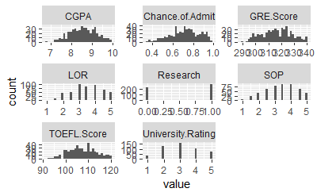

```r
# Checking the histogram of each of the columns
data %>% select(-Serial.No.) %>% gather() %>% ggplot(aes(value)) + facet_wrap(~ key, scales = 'free') +
  geom_histogram()
```

## Correlation between the variables

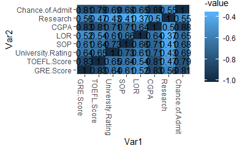

```r
correlation <- cor(data %>% select(-Serial.No.)) %>% round(2)
correlation %>% melt() %>% ggplot(aes(Var1, Var2, fill = -value)) + geom_tile() + geom_text(aes(label = value)) + theme(axis.text.x=element_text(angle = -90, hjust = 0))
```

The most important features for the admission are CGPA, GRE Score and TOEFL Score.

## Arranging the data

We can see that some of the features are discrete and others are cotinuous, but the continuous ones are not in the same scale. To address this we will scale them from 0 to 100. After that we will change the discrete features to factors, so we can start training our data.

```r
new_data <- data %>%
  mutate(CGPA = rescale(CGPA, to = c(0, 100)),
         GRE.Score = rescale(GRE.Score, to = c(0,100)),
         TOEFL.Score = rescale(TOEFL.Score, to = c(0, 100))) %>%
  mutate(CGPA = CGPA - mean(CGPA), GRE.Score = GRE.Score - mean(GRE.Score),
         TOEFL.Score = TOEFL.Score - mean(TOEFL.Score),
         SOP = factor(SOP), University.Rating = factor(University.Rating),
         Research = factor(Research), LOR = factor(LOR)) %>% select(-Serial.No.)
```

## Creating the training and test set

```r
test_index <- createDataPartition(data$Chance.of.Admit, times = 1, p = 0.2, list = F)
test_set <- new_data[test_index,]
train_set <- new_data[-test_index,]
```

## Training models

We change the chance to admit to 0 or 1, 1 if the chance to admit is highter than 0.8, else it is 0. We do this so we can test the models for accuracy

```r
factor_train_set <- train_set %>%
  mutate(Chance.of.Admit = factor(ifelse(Chance.of.Admit < 0.8, 0, 1)))
factor_test_set <- test_set %>%
  mutate(Chance.of.Admit = factor(ifelse(Chance.of.Admit < 0.8, 0, 1)))
```

### GLM

Our first model will be GLM

```r
glm_train <- train(Chance.of.Admit ~. , method = 'glm', data = factor_train_set)
glm_pred <- predict(glm_train, factor_test_set)
glm_confusion <- confusionMatrix(glm_pred, factor_test_set$Chance.of.Admit)
glm_plot <- data.frame(glm_confusion$table) %>% ggplot(aes(Reference, Prediction)) +
  geom_tile(aes(fill = -Freq)) +
  geom_text(aes(Reference, Prediction, label = Freq)) +
  ggtitle('GLM Results')
glm_confusion
```

```
Confusion Matrix and Statistics

          Reference
Prediction  0  1
         0 66  3
         1  6 26

               Accuracy : 0.9109
                 95% CI : (0.8376, 0.9584)
    No Information Rate : 0.7129
    P-Value [Acc > NIR] : 1.082e-06

                  Kappa : 0.7889
 Mcnemar's Test P-Value : 0.505

            Sensitivity : 0.9167
            Specificity : 0.8966
         Pos Pred Value : 0.9565
         Neg Pred Value : 0.8125
             Prevalence : 0.7129
         Detection Rate : 0.6535
   Detection Prevalence : 0.6832
      Balanced Accuracy : 0.9066

       'Positive' Class : 0
```

### Naive Bayes

```r
nb_train <- train(Chance.of.Admit ~. , method = 'nb', data = factor_train_set)
nb_pred <- predict(nb_train, factor_test_set)
nb_confusion <- confusionMatrix(nb_pred, factor_test_set$Chance.of.Admit)
nb_plot <- data.frame(nb_confusion$table) %>% ggplot(aes(Reference, Prediction)) +
  geom_tile(aes(fill = -Freq)) +
  geom_text(aes(Reference, Prediction, label = Freq)) +
  ggtitle('NB Results')
nb_confusion
```

```
Confusion Matrix and Statistics

          Reference
Prediction  0  1
         0 70  3
         1  2 26

               Accuracy : 0.9505
                 95% CI : (0.8882, 0.9837)
    No Information Rate : 0.7129
    P-Value [Acc > NIR] : 1.367e-09

                  Kappa : 0.8778
 Mcnemar's Test P-Value : 1

            Sensitivity : 0.9722
            Specificity : 0.8966
         Pos Pred Value : 0.9589
         Neg Pred Value : 0.9286
             Prevalence : 0.7129
         Detection Rate : 0.6931
   Detection Prevalence : 0.7228
      Balanced Accuracy : 0.9344

       'Positive' Class : 0
```

### KNN

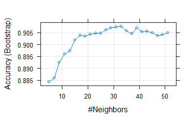

```r
knn_train <- train(Chance.of.Admit ~., method = 'knn', data = factor_train_set,
                   tuneGrid = data.frame(k = seq(5, 51, 2)))
knn_pred <- predict(knn_train, factor_test_set)
knn_confusion <- confusionMatrix(knn_pred, factor_test_set$Chance.of.Admit)
# Plot showing the tuning parameters
plot(knn_train)
```

```r
knn_plot <- data.frame(knn_confusion$table) %>% ggplot(aes(Reference, Prediction)) +
  geom_tile(aes(fill = -Freq)) +
  geom_text(aes(Reference, Prediction, label = Freq)) +
  ggtitle('KNN Results')
knn_confusion
```

```
Confusion Matrix and Statistics

          Reference
Prediction  0  1
         0 67  2
         1  5 27

               Accuracy : 0.9307
                 95% CI : (0.8624, 0.9717)
    No Information Rate : 0.7129
    P-Value [Acc > NIR] : 5.126e-08

                  Kappa : 0.8358
 Mcnemar's Test P-Value : 0.4497

            Sensitivity : 0.9306
            Specificity : 0.9310
         Pos Pred Value : 0.9710
         Neg Pred Value : 0.8438
             Prevalence : 0.7129
         Detection Rate : 0.6634
   Detection Prevalence : 0.6832
      Balanced Accuracy : 0.9308

       'Positive' Class : 0
```

### Random Forest

```r
rf_train <- train(Chance.of.Admit ~., method = 'rf', data = factor_train_set)
rf_pred <- predict(rf_train, factor_test_set)
rf_confusion <- confusionMatrix(rf_pred, factor_test_set$Chance.of.Admit)
rf_plot <- data.frame(rf_confusion$table) %>% ggplot(aes(Reference, Prediction)) +
  geom_tile(aes(fill = -Freq)) +
  geom_text(aes(Reference, Prediction, label = Freq)) +
  ggtitle('RF Results')
rf_confusion
```

```
Confusion Matrix and Statistics

          Reference
Prediction  0  1
         0 65  2
         1  7 27

               Accuracy : 0.9109
                 95% CI : (0.8376, 0.9584)
    No Information Rate : 0.7129
    P-Value [Acc > NIR] : 1.082e-06

                  Kappa : 0.793
 Mcnemar's Test P-Value : 0.1824

            Sensitivity : 0.9028
            Specificity : 0.9310
         Pos Pred Value : 0.9701
         Neg Pred Value : 0.7941
             Prevalence : 0.7129
         Detection Rate : 0.6436
   Detection Prevalence : 0.6634
      Balanced Accuracy : 0.9169

       'Positive' Class : 0
```

### Ensemble

With all the predictions from the previous models, we can build an ensemble. The ensemble will take the majority of votes of each model and create its prediction.

```r
ensemble_df <- data.frame(rf_pred, knn_pred, nb_pred, glm_pred)
votes <- rowMeans(ensemble_df == '1')
ensemble_pred <- ifelse(votes > 0.5, '1', '0')
ensemble_confusion <- confusionMatrix(factor(ensemble_pred), factor_test_set$Chance.of.Admit)
ensemble_plot <- data.frame(ensemble_confusion$table) %>% ggplot(aes(Reference, Prediction)) +
  geom_tile(aes(fill = -Freq)) +
  geom_text(aes(Reference, Prediction, label = Freq)) +
  ggtitle('Ensemble Results')
ensemble_confusion
```

```
Confusion Matrix and Statistics

          Reference
Prediction  0  1
         0 68  2
         1  4 27

               Accuracy : 0.9406
                 95% CI : (0.8752, 0.9779)
    No Information Rate : 0.7129
    P-Value [Acc > NIR] : 9.084e-09

                  Kappa : 0.8578
 Mcnemar's Test P-Value : 0.6831

            Sensitivity : 0.9444
            Specificity : 0.9310
         Pos Pred Value : 0.9714
         Neg Pred Value : 0.8710
             Prevalence : 0.7129
         Detection Rate : 0.6733
   Detection Prevalence : 0.6931
      Balanced Accuracy : 0.9377

       'Positive' Class : 0
```

## Results and choosing the best model

Let’s look at our results until now. First let’s plot all the confusion matrices heatmaps.

[figure not shown]

```r
grid.arrange(rf_plot, nb_plot, rf_plot, ensemble_plot, glm_plot, knn_plot)
```

And now a table with the parameters we will be looking at.

```r
enb_df <- data.frame(naive_bayes = nb_confusion$byClass[1:3], ensemble = ensemble_confusion$byClass[1:3],
                     knn = knn_confusion$byClass[1:3], glm = glm_confusion$byClass[1:3],
                     random_forest = rf_confusion$byClass[1:3])
enb_df['Accuracy',] <- c(nb_confusion$overall['Accuracy'], ensemble_confusion$overall['Accuracy'],
                         knn_confusion$overall['Accuracy'], glm_confusion$overall['Accuracy'],
                         rf_confusion$overall['Accuracy'])
enb_df
```

|  | naive_bayes | ensemble | knn | glm | random_forest |
| --- | --- | --- | --- | --- | --- |
| Sensitivity | 0.9722222 | 0.9444444 | 0.9305556 | 0.9166667 | 0.9027778 |
| Specificity | 0.8965517 | 0.9310345 | 0.9310345 | 0.8965517 | 0.9310345 |
| Pos Pred Value | 0.9589041 | 0.9714286 | 0.9710145 | 0.9565217 | 0.9701493 |
| Accuracy | 0.9504950 | 0.9405941 | 0.9306931 | 0.9108911 | 0.9108911 |